# Data format (csfmt_rts_data_v1)

## csfmt_rts_data_v1

This document presents the data format `csfmt_rts_data_v1`.

`csfmt_rts_data_v1` is the data format that the CSIDS team recommends using for the real-time surveillance of infectious diseases.

## Style

**Language**

English is the primary language for our code.

Names that are abbreviations or in Norwegian are kept as they are: data sources such as `msis`, `daar`, `sysvak`, `normomo`.

**Capital letters**

Capital letters are to be avoided whenever possible. This is also the case in filenames (e.g. `data.rds` is preferred to `data.RDS`)

**snake_case or camelCase?**

Use snake_case.

**Timestamping of file names**

In results (e.g. reports), an indicator of time when the files are created are necessary. It allows us to find which one is the most recent version of files with the same names, and it allows easy tracking of an Airflow error.

e.g. `Epidemiologisk_situasjonsrapport_2021-05-31_0659.docx` for a report generated on May 31, 2021 06:59 AM.

## Ordering of variables

Sometimes variables need to be ordered. Variables should be ordered as follows:

- time
- location
- age
- sex

e.g. A database table could be called `msis_by_time_location_age_sex` or a filename could be called `2020_oslo_05-10_male.xlsx`

## Time

Time functions can be obtained from [cstime](https://www.csids.no/cstime/). Missing time data should be coded as `NA`. Uncommon/internal use is demarcated by a line through the text.

Valid times in the csverse format

[output not shown]

<sup>1</sup> isoweek (numeric) is used when it is a standalone variable.  
<sup>2</sup> isoweek (character) is only used internally within isoyearweek. Internal use is demarcated by a line through the text.  
<sup>3</sup> isoyear (numeric) is used when it is a standalone variable.  
<sup>4</sup> isoyear (character) is only used internally within isoyearweek. Internal use is demarcated by a line through the text.  
<sup>5</sup> If the event is ongoing, then the 'to' date should be 9999_09_09.

### Approved events

The following are approved events:

Approved events

| granularity_time | definition |
| --- | --- |
| event_covid19_norway_2020_02_21_to_9999_09_09 | Covid-19 outbreak in Norway (on-going). |
| event_covid19_norway_vaccination_2020_12_02_to_9999_09_09 | Covid-19 vaccination campaign in Norway (on-going). |

## Location

Locations can be obtained from [csdata](https://www.csids.no/csdata/). Valid locations (and location types) are available in `csdata::nor_locations_names()`. Uncommon/internal use is demarcated by a line through the text.

Valid locations and location types in the csverse format

| Geo (Granularity) | N | Examples location_code<sup>1</sup> | Examples location_name<sup>2</sup> | Examples location_name_description_nb<sup>3</sup> | Examples location_name_file_nb_utf<sup>4</sup> | Examples location_name_file_nb_ascii<sup>5</sup> |
| --- | --- | --- | --- | --- | --- | --- |
| nation | 1 | nation_nor | Norge | Norge | Norge | Norge |
| county | 15 | county_nor42 | Agder | Agder (fylke) | Agder_fylke | Agder_fylke |
| notmainlandcounty | 2 | notmainlandcounty_nor22 | Utenfor fastlands-Norge (Jan Mayen) | Utenfor fastlands-Norge (Jan Mayen) (fylke) | Utenfor_fastlands_Norge_Jan_Mayen_fylke | Utenfor_fastlands_Norge_Jan_Mayen_fylke |
| missingcounty | 1 | missingcounty_nor99 | Ukjent fylke | Ukjent fylke (fylke) | Ukjent_fylke | Ukjent_fylke |
| municip | 357 | municip_nor1820 | Alstahaug | Alstahaug (kommune i Nordland) | Alstahaug_kommune_i_Nordland | Alstahaug_kommune_i_Nordland |
| notmainlandmunicip | 2 | notmainlandmunicip_nor2200 | Jan Mayen | Jan Mayen (kommune i Utenfor fastlands-Norge (Jan Mayen)) | Jan_Mayen_kommune_i_Utenfor_fastlands_Norge_Jan_Mayen | Jan_Mayen_kommune_i_Utenfor_fastlands_Norge_Jan_Mayen |
| missingmunicip | 1 | missingmunicip_nor9999 | Ukjent kommune | Ukjent kommune (kommune i Ukjent fylke) | Ukjent_kommune_i_Ukjent_fylke | Ukjent_kommune_i_Ukjent_fylke |
| wardoslo | 15 | wardoslo_nor030112 | Alna | Alna (bydel i Oslo) | Alna_bydel_i_Oslo | Alna_bydel_i_Oslo |
| wardbergen | 8 | wardbergen_nor460101 | Arna | Arna (bydel i Bergen) | Arna_bydel_i_Bergen | Arna_bydel_i_Bergen |
| wardstavanger | 9 | wardstavanger_nor110303 | Eiganes og Våland | Eiganes og Våland (bydel i Stavanger) | Eiganes_og_Våland_bydel_i_Stavanger | Eiganes_og_Valand_bydel_i_Stavanger |
| wardtrondheim | 4 | wardtrondheim_nor500104 | Heimdal | Heimdal (bydel i Trondheim) | Heimdal_bydel_i_Trondheim | Heimdal_bydel_i_Trondheim |
| extrawardoslo | 2 | extrawardoslo_nor030117 | Marka | Marka (bydel i Oslo) | Marka_bydel_i_Oslo | Marka_bydel_i_Oslo |
| missingwardbergen | 1 | missingwardbergen_nor460199 | Ukjent bydel i Bergen | Ukjent bydel i Bergen (bydel i Bergen) | Ukjent_bydel_i_Bergen | Ukjent_bydel_i_Bergen |
| missingwardoslo | 1 | missingwardoslo_nor030199 | Ukjent bydel i Oslo | Ukjent bydel i Oslo (bydel i Oslo) | Ukjent_bydel_i_Oslo | Ukjent_bydel_i_Oslo |
| missingwardstavanger | 1 | missingwardstavanger_nor110399 | Ukjent bydel i Stavanger | Ukjent bydel i Stavanger (bydel i Stavanger) | Ukjent_bydel_i_Stavanger | Ukjent_bydel_i_Stavanger |
| missingwardtrondheim | 1 | missingwardtrondheim_nor500199 | Ukjent bydel i Trondheim | Ukjent bydel i Trondheim (bydel i Trondheim) | Ukjent_bydel_i_Trondheim | Ukjent_bydel_i_Trondheim |
| baregion<sup>6</sup> | 159 | baregion_nor111 | Alstahaug | Alstahaug (BA-region) | Alstahaug_BA_region | Alstahaug_BA_region |
| georegion | 5 | georegion_nor1 | Nord-Norge | Nord-Norge (landsdel) | Nord_Norge_landsdel | Nord_Norge_landsdel |
| mtregion | 5 | mtregion_nor4 | Midt-Norge | Midt-Norge (Mattilsynet-region) | Midt_Norge_Mattilsynet_region | Midt_Norge_Mattilsynet_region |
| lab | 26 | lab_nor000030 | Akershus Universitetssykehus | Akershus Universitetssykehus (lab) | Akershus_Universitetssykehus_lab | Akershus_Universitetssykehus_lab |

<sup>1</sup> **location_code**: Used a) **inside datasets** and b) in data **file names** for transfer of data/results between analytic systems. All values are unique.  
<sup>2</sup> **location_name**: Used (rarely) **inside results** (figures, tables, documents). Can be confusing as some names are duplicated. Its rare usage is demarcated by a line through the text.  
<sup>3</sup> **location_name_description_nb**: Used (frequently) **inside results** (figures, tables, documents). All values are unique.  
<sup>4</sup> **location_name_file_nb_utf**: Used (frequently) in the **file names** for results (figures, tables, documents). All values are unique.  
<sup>5</sup> **location_name_file_nb_ascii**: Used (rarely) in the **file names** for results (figures, tables, documents). Used if file systems have problems with the Norwegian letters æøå. All values are unique.  
<sup>6</sup> Bo- og arbeidsmarkedsregioner. Housing and labor market regions.

## Ages

Ages should be coded as characters and should always contain 3 digits. If it is an age range, the two ages are joined by an underscore (e.g. `005_010`).

Use `085p` instead of `>=085` or `85+`, as this will allow for an easy conversion from long to wide formatted data.

Valid ages in the csverse format

| Value | class | Definition |
| --- | --- | --- |
| "000" | character | One year age group (0 year olds) |
| "079" | character | One year age group(79 year olds) |
| "000_004" | character | Age span of 0-4 year olds |
| "065p" | character | Age span of >=65 year olds |
| "missing" | character | Missing/unknown |
| "total" | character | Everyone |

This format will help your data be easily sorted, kept in the right order, and generate valid variable names if converted to wide-format.

Missing ages should be coded as “missing”.

## Sex

Sex should be coded as characters.

Valid sexes in the csverse format

| Value | class | Definition |
| --- | --- | --- |
| "male" | character | Male |
| "female" | character | Female |
| "missing" | character | Missing/unknown |
| "total" | character | Everyone |

Missing sexes should be coded as “missing”.

## Unified columns

All datasets in the csverse format csfmt_rts_data_v1 will contain these 16 columns.

Time conversion functions can be found in package [cstime](https://www.csids.no/cstime/).

Unified columns (16) in the csverse format csfmt_rts_data_v1

| Variable | Accepted values | Definition |
| --- | --- | --- |
| granularity_time | "date", "isoyearweek", "isoyear", "event_*_*_to_*" (Time) | Granularity of time |
| granularity_geo | "nation", "county", "notmainlandcounty", "missingcounty", "municip", "notmainlandmunicip", "missingmunicip", "wardoslo", "wardbergen", "wardstavanger", "wardtrondheim", "extrawardoslo", "missingwardbe… | Granularity of geography |
| country_iso3 | "nor", "den", "swe", "fin" | ISO3 country code. |
| location_code | "norge", "countyXX", "municipXXXX", ... (Location) | Location code |
| border | 2020 | The borders (kommunesammenslåing) that location_code represents |
| age | "000", "001", "000_004", "065p", "total", "missing", ... (Age) | Age in years |
| sex | "male", "female", "total", "missing" (Sex) | Sex |
| isoyear | YYYY | Use function cstime::isoyear_n |
| isoweek | 1, 2, ..., 53 | Use functions cstime::*_to_isoweek_n |
| isoyearweek | "YYYY-WW" | Use function cstime::isoyearweek_c |
| season | "YYYY/YYYY" | Seasons start in week 30 and finish in week 29. |
| seasonweek | 1, 2, ..., 23, 23.5, 24, ..., 52 | isoweek = 30 -> seasonweek = 1. isoweek = 52 -> seasonweek = 23. isoweek = 53 -> seasonweek = 23.5. isoweek = 1 -> seasonweek = 24. isoweek = 29 -> seasonweek = 52. This is used primarily for plotting… |
| calyear | ..., 2020, 2021, ... | Calendar years. |
| calmonth | 1, 2, ..., 11, 12 | Calendar months. |
| calyearmonth | "2021-M01" |  |
| date | YYYY-MM-DD | Always corresponds to the last date in the time period. E.g. if granularity_time=='isoweek' then date is the Sunday of that week. If granularity_time == 'event_*_date1_to_9999_09_09' then date is 9999… |

### Smart assignment

`csfmt_rts_data_v1` does smart assignment for time and geography.

When the **variables in bold** are assigned using `:=`, the listed variables will be automatically imputed.

**location_code**:

- granularity_geo
- country_iso3

**isoyear**:

- granularity_time
- isoweek
- isoyearweek
- season
- seasonweek
- calyear
- calmonth
- calyearmonth
- date

**isoyearweek**:

- granularity_time
- isoyear
- isoweek
- season
- seasonweek
- calyear
- calmonth
- calyearmonth
- date

**date**:

- granularity_time
- isoyear
- isoweek
- isoyearweek
- season
- seasonweek
- calyear
- calmonth
- calyearmonth

## Context-specific columns

Variable names that are not part of the unified columns are called context-specific columns, and are made up of 2 mandatory (description, format) and 5 optional (time, statistics, forecast, censored/status, formatted) sections, separated by underscores.

The format is as follows:

```yaml
description[_time][_statistics]_format[_forecast][_censored/status][_formatted]
```

Where `[blah]` indicates an optional argument. It is rare that all of the optional arguments will be used at the same time.

Context-specific columns in the csverse format csfmt_rts_data_v1

|  | Examples | Definition |
| --- | --- | --- |
| Description (mandatory) |  |  |
|  | deaths, consultations, cases | Simple. |
|  | deaths_registered, deaths_nowcasted, deaths_nowcasted_baseline | Slightly complex. |
|  | hospital_deaths, vax_administered_dose_1, vax_coverage_dose_1, msis_cases_testdate, msis_cases_regdate | Complex. |
|  | outcome, exposure, model | Generally used in conjunction with 'tag' (see 'Format'). |
| Time (optional) |  |  |
|  | sum0_13 | The sum of values for the given date and the previous 13 days. If granularity_time=='isoyearweek' and the given isoweek has full data, then it is the sum of values for the Sunday in the given isoweek … |
|  | sum0_999999 | The sum of all days with data. |
|  | daymean0_13 | The mean of all the daily observations for the given date and the previous 13 days. |
|  | isoweekmean0_13 | The mean of all the weekly observations for the given date and the previous 13 days (i.e. the last 2 weeks). |
| Statistics (optional) |  |  |
|  | predinterval_q02x5 | Prediction interval for the baseline (2.5th quantile). 'x' is used to denominate a decimal point, so that we can differentiate between 100 (100x0) and 10.0 (10x0). |
|  | credintervalobs_q02x5 | Credibility interval for a new observation of data according to the baseline model (2.5th quantile). |
|  | credintervalmean_q02x5 | Credibility interval for the mean of the data according to the baseline model (2.5th quantile). |
|  | *interval*_q50x0 | Generally speaking, the 50th percentile is the expected value. |
| Format (mandatory) |  |  |
|  | id/tag | Used when data is in long format, to indicate an id variable. Frequently combined with descriptions of 'outcome', 'exposure', 'model'. id is used for numeric columns. tag is used for character columns… |
|  | n | Numerical value |
|  | pr1 | Proportion (between 0 and 1) |
|  | pr100 | Percentage (between 0 and 100) |
|  | pr100000, prX | Rate per X |
|  | date | Date |
|  | bool | TRUE/FALSE |
| Forecast (optional) |  |  |
|  | forecast | TRUE/FALSE. Only used when a column contains both forecasted and non-forecasted data. |
| Censored/Status (optional) |  |  |
|  | censored | TRUE/FALSE |
|  | status | Character. |

### Examples

In the below examples, the description, time, statistics, format, and censor/status sections are separated by /.

An example relating to death and nowcasting:

- **deaths_registered/_n**: Number of registered deaths.
- **deaths_nowcasted/_n**: Number of registered deaths, corrected for registration delay (nowcasting).
- **deaths_nowcasted/_n_forecast**: Has ‘deaths_nowcasted_n’ been forecasted (i.e. nowcasted)?
- **deaths_nowcasted/_n/_censored**: Has ‘deaths_nowcasted_n’ been censored?
- **deaths_nowcasted/_n/_status**: Status of ‘deaths_nowcasted_n’ in relation to ’deaths_nowcasted_baseline_credintervalobs_q*_n’.
- **deaths_nowcasted/_credintervalobs_q02x5/_n**: The 2.5th quantile of where we expect the real number of registered deaths (Bayesian).
- **deaths_nowcasted_baseline/_predinterval_q02x5/_n**: The 2.5th quantile of an expected new observation of nowcasted deaths (frequentist).
- **deaths_nowcasted_baseline/_predinterval_q97x5/_n**: The 97.5th quantile of an expected new observation of nowcasted deaths (frequentist).
- **deaths_nowcasted_baseline/_credintervalobs_q02x5/_n**: The 2.5th quantile of where we expect an observation of nowcasted deaths (Bayesian).
- **deaths_nowcasted_baseline/_credintervalmean_q02x5/_n**: The 2.5th quantile of the mean of nowcasted deaths (Bayesian).

An example relating to number of covid-19 cases:

- **covid19_cases_regdate/_n**: Number of covid-19 cases by registration date.
- **covid19_cases_testdate/_n**: Number of covid-19 cases by testing date.
- **covid19_cases_testdate/_sum0_13/_n**: The sum of 14 days of cases. When granularity_time==‘date’, date==‘2022-01-20’, and the current date is ‘2022-02-07’, the value is the sum of covid19_cases_testdate_n between ‘2022-01-07’ and ‘2022-01-20’. When granularity_time==‘isoyearweek’, isoyearweek==‘2022-03’, and the current date is ‘2022-02-07’ (Monday in isoyearweek ‘2022-06’) the value is the sum of covid19_cases_testdate_n between ‘2022-01-10’ (Monday in isoyearweek ‘2022-02’) and ‘2022-01-23’ (Sunday in isoyearweek ‘2022-03’). When granularity_time==‘isoyearweek’, isoyearweek==‘2022-06’, and the current date is ‘2022-02-07’ (Monday in isoyearweek ‘2022-06’), the value is the sum of covid19_cases_testdate_n between the last day with available data and 13 days prior. When granularity_time==‘event_covid19_norway_2020_02_21_to_9999_09_09’, the value is the sum of covid19_cases_testdate_n between the last day with available data and 13 days prior.
- **covid19_cases_testdate/_sum0_999999/_n**: The sum of all recorded days of cases.
- **covid19_cases_testdate/_sum0_13/_n**: Expected number of nowcasted deaths (i.e. baseline).
- **deaths_nowcasted_baseline/_predinterval_q02x5/_n**: The 2.5th quantile of an expected new observation of nowcasted deaths (frequentist).
- **deaths_nowcasted_baseline/_predinterval_q97x5/_n**: The 97.5th quantile of an expected new observation of nowcasted deaths (frequentist).
- **deaths_nowcasted_baseline/_credintervalobs_q02x5/_n**: The 2.5th quantile of where we expect an observation of nowcasted deaths (Bayesian).
- **deaths_nowcasted_baseline/_credintervalmean_q02x5/_n**: The 2.5th quantile of the mean of nowcasted deaths (Bayesian).

An example relating to number of covid-19 tests:

- **covid19_testevents/_n**: Number of covid-19 test events (i.e. a person getting tested within a 7 day period).
- **covid19_testevents_pos/_pr1**: Proportion (0-1) of covid-19 test events that were positive.
- **covid19_testevents_pos/_pr100**: Percentage (0-100) of covid-19 test events that were positive.
- **covid19_testevents_pos/_sum0_13/_pr100**: Percentage (0-100) of covid-19 test events that were positive over the last 14 days.
- **covid19_testevents_pos/_daymean0_13/_pr100**: For each of the last 14 days, calculate the percentage (0-100) of covid-19 test events that were positive, and then take the mean of these 14 values.
- **covid19_testevents_pos/_isoweekmean0_13/_pr100**: For each of the last 7 day periods (0-6 days, 7-13 days), calculate the percentage (0-100) of covid-19 test events that were positive, and then take the mean of these 2 values.

An example relating to vaccination:

- **covid19_vax_administered_dose_1/_n**: Number of people who received their first dose during this day/isoweek/event. The corresponding age is permanently fixed (a person who received their first dose when 21, will always have received their first dose when 21).
- **covid19_vax_coverage_dose_1/_n**: Number of people who (on the last day of the day/isoweek/event) have received 1 dose of vaccine. The corresponding age is fixed at the last day of the day/isoweek/event.

## In action

```r
d <- cstidy::generate_test_data()[1:5]
cstidy::set_csfmt_rts_data_v1(d)

# Looking at the dataset
d[]
```

```
#>    granularity_time granularity_geo country_iso3 location_code border  age  sex
#> 1:      isoyearweek          county          nor  county_nor42     NA <NA> <NA>
#> 2:      isoyearweek          county          nor  county_nor32     NA <NA> <NA>
#> 3:      isoyearweek          county          nor  county_nor33     NA <NA> <NA>
#> 4:      isoyearweek          county          nor  county_nor56     NA <NA> <NA>
#> 5:      isoyearweek          county          nor  county_nor34     NA <NA> <NA>
#>    isoyear isoweek isoyearweek    season seasonweek calyear calmonth
#> 1:    2022       3     2022-03 2021/2022         26      NA       NA
#> 2:    2022       3     2022-03 2021/2022         26      NA       NA
#> 3:    2022       3     2022-03 2021/2022         26      NA       NA
#> 4:    2022       3     2022-03 2021/2022         26      NA       NA
#> 5:    2022       3     2022-03 2021/2022         26      NA       NA
#>    calyearmonth       date deaths_n
#> 1:         <NA> 2022-01-23        6
#> 2:         <NA> 2022-01-23        4
#> 3:         <NA> 2022-01-23        7
#> 4:         <NA> 2022-01-23        5
#> 5:         <NA> 2022-01-23        3
```

```r
# Smart assignment of time columns (note how granularity_time, isoyear, isoyearweek, date all change)
d[1, isoyearweek := "2021-01"]
d
```

```
#>    granularity_time granularity_geo country_iso3 location_code border  age  sex
#> 1:      isoyearweek          county          nor  county_nor42     NA <NA> <NA>
#> 2:      isoyearweek          county          nor  county_nor32     NA <NA> <NA>
#> 3:      isoyearweek          county          nor  county_nor33     NA <NA> <NA>
#> 4:      isoyearweek          county          nor  county_nor56     NA <NA> <NA>
#> 5:      isoyearweek          county          nor  county_nor34     NA <NA> <NA>
#>    isoyear isoweek isoyearweek    season seasonweek calyear calmonth
#> 1:    2021       1     2021-01 2020/2021         24      NA       NA
#> 2:    2022       3     2022-03 2021/2022         26      NA       NA
#> 3:    2022       3     2022-03 2021/2022         26      NA       NA
#> 4:    2022       3     2022-03 2021/2022         26      NA       NA
#> 5:    2022       3     2022-03 2021/2022         26      NA       NA
#>    calyearmonth       date deaths_n
#> 1:         <NA> 2021-01-10        6
#> 2:         <NA> 2022-01-23        4
#> 3:         <NA> 2022-01-23        7
#> 4:         <NA> 2022-01-23        5
#> 5:         <NA> 2022-01-23        3
```

```r
# Smart assignment of time columns (note how granularity_time, isoyear, isoyearweek, date all change)
d[2, isoyear := 2019]
d
```

```
#>    granularity_time granularity_geo country_iso3 location_code border  age  sex
#> 1:      isoyearweek          county          nor  county_nor42     NA <NA> <NA>
#> 2:          isoyear          county          nor  county_nor32     NA <NA> <NA>
#> 3:      isoyearweek          county          nor  county_nor33     NA <NA> <NA>
#> 4:      isoyearweek          county          nor  county_nor56     NA <NA> <NA>
#> 5:      isoyearweek          county          nor  county_nor34     NA <NA> <NA>
#>    isoyear isoweek isoyearweek    season seasonweek calyear calmonth
#> 1:    2021       1     2021-01 2020/2021         24      NA       NA
#> 2:    2019      52     2019-52      <NA>         NA      NA       NA
#> 3:    2022       3     2022-03 2021/2022         26      NA       NA
#> 4:    2022       3     2022-03 2021/2022         26      NA       NA
#> 5:    2022       3     2022-03 2021/2022         26      NA       NA
#>    calyearmonth       date deaths_n
#> 1:         <NA> 2021-01-10        6
#> 2:         <NA> 2019-12-29        4
#> 3:         <NA> 2022-01-23        7
#> 4:         <NA> 2022-01-23        5
#> 5:         <NA> 2022-01-23        3
```

```r
# Smart assignment of time columns (note how granularity_time, isoyear, isoyearweek, date all change)
d[4:5, date := as.Date("2020-01-01")]
d
```

```
#>    granularity_time granularity_geo country_iso3 location_code border  age  sex
#> 1:      isoyearweek          county          nor  county_nor42     NA <NA> <NA>
#> 2:          isoyear          county          nor  county_nor32     NA <NA> <NA>
#> 3:      isoyearweek          county          nor  county_nor33     NA <NA> <NA>
#> 4:             date          county          nor  county_nor56     NA <NA> <NA>
#> 5:             date          county          nor  county_nor34     NA <NA> <NA>
#>    isoyear isoweek isoyearweek    season seasonweek calyear calmonth
#> 1:    2021       1     2021-01 2020/2021         24      NA       NA
#> 2:    2019      52     2019-52      <NA>         NA      NA       NA
#> 3:    2022       3     2022-03 2021/2022         26      NA       NA
#> 4:    2020       1     2020-01 2019/2020         24    2020        1
#> 5:    2020       1     2020-01 2019/2020         24    2020        1
#>    calyearmonth       date deaths_n
#> 1:         <NA> 2021-01-10        6
#> 2:         <NA> 2019-12-29        4
#> 3:         <NA> 2022-01-23        7
#> 4:     2020-M01 2020-01-01        5
#> 5:     2020-M01 2020-01-01        3
```

```r
# Smart assignment fails when multiple time columns are set
d[1, c("isoyear", "isoyearweek") := .(2021, "2021-01")]
d
```

```
#>    granularity_time granularity_geo country_iso3 location_code border  age  sex
#> 1:      isoyearweek          county          nor  county_nor42     NA <NA> <NA>
#> 2:          isoyear          county          nor  county_nor32     NA <NA> <NA>
#> 3:      isoyearweek          county          nor  county_nor33     NA <NA> <NA>
#> 4:             date          county          nor  county_nor56     NA <NA> <NA>
#> 5:             date          county          nor  county_nor34     NA <NA> <NA>
#>    isoyear isoweek isoyearweek    season seasonweek calyear calmonth
#> 1:    2021       1     2021-01 2020/2021         24      NA       NA
#> 2:    2019      52     2019-52      <NA>         NA      NA       NA
#> 3:    2022       3     2022-03 2021/2022         26      NA       NA
#> 4:    2020       1     2020-01 2019/2020         24    2020        1
#> 5:    2020       1     2020-01 2019/2020         24    2020        1
#>    calyearmonth       date deaths_n
#> 1:         <NA> 2021-01-10        6
#> 2:         <NA> 2019-12-29        4
#> 3:         <NA> 2022-01-23        7
#> 4:     2020-M01 2020-01-01        5
#> 5:     2020-M01 2020-01-01        3
```

```r
# Smart assignment of geo columns
d[1, c("location_code") := .("norge")]
d
```

```
#>    granularity_time granularity_geo country_iso3 location_code border  age  sex
#> 1:      isoyearweek          nation          nor         norge     NA <NA> <NA>
#> 2:          isoyear          county          nor  county_nor32     NA <NA> <NA>
#> 3:      isoyearweek          county          nor  county_nor33     NA <NA> <NA>
#> 4:             date          county          nor  county_nor56     NA <NA> <NA>
#> 5:             date          county          nor  county_nor34     NA <NA> <NA>
#>    isoyear isoweek isoyearweek    season seasonweek calyear calmonth
#> 1:    2021       1     2021-01 2020/2021         24      NA       NA
#> 2:    2019      52     2019-52      <NA>         NA      NA       NA
#> 3:    2022       3     2022-03 2021/2022         26      NA       NA
#> 4:    2020       1     2020-01 2019/2020         24    2020        1
#> 5:    2020       1     2020-01 2019/2020         24    2020        1
#>    calyearmonth       date deaths_n
#> 1:         <NA> 2021-01-10        6
#> 2:         <NA> 2019-12-29        4
#> 3:         <NA> 2022-01-23        7
#> 4:     2020-M01 2020-01-01        5
#> 5:     2020-M01 2020-01-01        3
```

```r
# Collapsing down to different levels, and healing the dataset
# (so that it can be worked on further with regards to real time surveillance)
d[, .(deaths_n = sum(deaths_n), location_code = "norge"), keyby = .(granularity_time)] %>%
  cstidy::set_csfmt_rts_data_v1(create_unified_columns = TRUE) %>%
  print()
```

```
#>    granularity_time granularity_geo country_iso3 location_code border  age  sex
#> 1:             date          nation          nor         norge     NA <NA> <NA>
#> 2:          isoyear          nation          nor         norge     NA <NA> <NA>
#> 3:      isoyearweek          nation          nor         norge     NA <NA> <NA>
#>    isoyear isoweek isoyearweek season seasonweek calyear calmonth calyearmonth
#> 1:      NA      NA        <NA>   <NA>         NA      NA       NA         <NA>
#> 2:      NA      NA        <NA>   <NA>         NA      NA       NA         <NA>
#> 3:      NA      NA        <NA>   <NA>         NA      NA       NA         <NA>
#>    date deaths_n
#> 1: <NA>        8
#> 2: <NA>        4
#> 3: <NA>       13
```

```r
# Collapsing down to different levels, without healing the dataset and without
# removing the class csfmt_rts_data_v1 (this is uncommon)
d[, .(deaths_n = sum(deaths_n), location_code = "norge"), keyby = .(granularity_time)] %>%
  print()
```

```
#>    granularity_time deaths_n location_code
#> 1:             date        8         norge
#> 2:          isoyear        4         norge
#> 3:      isoyearweek       13         norge
```

```r
# Collapsing to different levels, and removing the class csfmt_rts_data_v1 because
# it is going to be used in new output/analyses
d[, .(deaths_n = sum(deaths_n), location_code = "norge"), keyby = .(granularity_time)] %>%
  cstidy::remove_class_csfmt_rts_data() %>%
  print()
```

```
#>    granularity_time deaths_n location_code
#> 1:             date        8         norge
#> 2:          isoyear        4         norge
#> 3:      isoyearweek       13         norge
```

## Expand time to

Sometimes you need to expand the number of rows in a dataset to a future time.

```r
cstidy::generate_test_data() %>%
  cstidy::set_csfmt_rts_data_v1() %>%
  dplyr::filter(location_code == "county03") %>%
  cstidy::expand_time_to(max_isoyearweek = "2022-08") %>%
  print()
```

```
#> Null data.table (0 rows and 0 cols)
```

## Time series

We might also need to identify how many time series are in one dataset.

```r
cstidy::generate_test_data() %>%
  cstidy::set_csfmt_rts_data_v1() %>%
  cstidy::unique_time_series()
```

[output not shown]

## Summary

We need a way to easily summarize the data structure of a dataset.

```r
cstidy::generate_test_data() %>%
  cstidy::set_csfmt_rts_data_v1() %>%
  summary()
```

```
#>
#> granularity_time
#> ✅ No errors
#>
#> granularity_geo
#> ✅ No errors
#>
#> country_iso3
#> ✅ No errors
#>
#> location_code
#> ✅ No errors
#>
#> border
#> ❌ Errors:
#> - NA exists (not allowed)
#>
#> age
#> ✅ No errors
#>
#> sex
#> ✅ No errors
#>
#> isoyear
#> ✅ No errors
#>
#> isoweek
#> ✅ No errors
#>
#> isoyearweek
#> ✅ No errors
#>
#> season
#> ✅ No errors
#>
#> seasonweek
#> ✅ No errors
#>
#> calyear
#> ✅ No errors
```

[output cut: 22 more lines]

```
#> sex (character):
#>  - <NA>  (n = 15)
#>  - total (n = 30)
#> isoyear (integer):
#>  - 2022 (n = 45)
#> isoweek (integer)
#> isoyearweek (character)
#> season (character):
#>  - 2021/2022 (n = 45)
#> seasonweek (numeric)
#> calyear (integer)
#> calmonth (integer)
#> calyearmonth (character)
#> date (Date)
#> deaths_n (integer)
```

## Identifying data structure of one column

We need a way to easily summarize the data structure of one column inside a dataset.

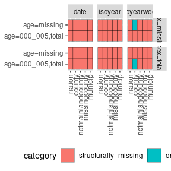

```r
cstidy::generate_test_data() %>%
  cstidy::set_csfmt_rts_data_v1() %>%
  cstidy::identify_data_structure("deaths_n") %>%
  plot()
```

## Reference (Location)

Locations can be obtained from [csdata](https://www.csids.no/csdata/). Valid locations (and location types) are available in `csdata::nor_locations_names()`.

Here we list as a reference table the valid `location_code`s and `location_name_description_nb`s (the two most commonly used locations).

Reference table of location_code and location_name_description_nb

| # | location_code | location_name_description_nb |
| --- | --- | --- |
| #1 | nation_nor | Norge |
| #2 | county_nor42 | Agder (fylke) |
| #3 | county_nor32 | Akershus (fylke) |
| #4 | county_nor33 | Buskerud (fylke) |
| #5 | county_nor56 | Finnmark-Finnmarku (fylke) |
| #6 | county_nor34 | Innlandet (fylke) |
| #7 | county_nor15 | Møre og Romsdal (fylke) |
| #8 | county_nor18 | Nordland (fylke) |
| #9 | county_nor03 | Oslo (fylke) |
| #10 | county_nor11 | Rogaland (fylke) |
| #11 | county_nor40 | Telemark (fylke) |
| #12 | county_nor55 | Troms (fylke) |
| #13 | county_nor50 | Trøndelag (fylke) |
| #14 | county_nor39 | Vestfold (fylke) |
| #15 | county_nor46 | Vestland (fylke) |
| #16 | county_nor31 | Østfold (fylke) |
| #17 | notmainlandcounty_nor22 | Utenfor fastlands-Norge (Jan Mayen) (fylke) |
| #18 | notmainlandcounty_nor21 | Utenfor fastlands-Norge (Svalbard) (fylke) |
| #19 | missingcounty_nor99 | Ukjent fylke (fylke) |
| #20 | municip_nor1820 | Alstahaug (kommune i Nordland) |
| #21 | municip_nor5601 | Alta (kommune i Finnmark-Finnmarku) |
| #22 | municip_nor3428 | Alvdal (kommune i Innlandet) |
| #23 | municip_nor4631 | Alver (kommune i Vestland) |
| #24 | municip_nor1871 | Andøy (kommune i Nordland) |
| #25 | municip_nor3124 | Aremark (kommune i Østfold) |
| #26 | municip_nor4203 | Arendal (kommune i Agder) |
| #27 | municip_nor3203 | Asker (kommune i Akershus) |
| #28 | municip_nor4645 | Askvoll (kommune i Vestland) |
| #29 | municip_nor4627 | Askøy (kommune i Vestland) |
| #30 | municip_nor1547 | Aukra (kommune i Møre og Romsdal) |

[output cut: 586 more lines]